# Tugas Praktikum 3 - Regresi dengan Peubah Lag

Sabitala Dinika G1401231089

## Packages

```r
library(dLagM)
library(dynlm)
library(MLmetrics)
library(lmtest)
library(car)
```

## Impor Data

```r
dt <- read.csv("~/punya dinoy/kuliah/Semester 5/MPDW/NewDelhi_Air_quality.csv")
head(dt)
```

```
##   X  AQI       CO      datetime        no2       o3      pm10     pm25
## 1 0 30.2 198.6027 2022-10-21:18 0.04685717 55.78995 10.486722 5.637410
## 2 1 28.2 197.6013 2022-10-21:19 0.04645554 54.93164 10.719325 4.618169
## 3 2 26.6 198.6027 2022-10-21:20 0.04685717 54.64554 11.155578 3.520902
## 4 3 25.0 201.9405 2022-10-21:21 0.04819594 55.07469 11.116206 2.225919
## 5 4 26.0 205.2784 2022-10-21:22 0.04886533 55.78995 10.405250 1.979471
## 6 5 26.0 208.6163 2022-10-21:23 0.05020411 56.50520  9.402518 1.792677
##         so2     timestamp_local       timestamp_utc         ts
## 1 0.3874302 2022-10-21T23:00:00 2022-10-21T18:00:00 1666375200
## 2 0.4097819 2022-10-22T00:00:00 2022-10-21T19:00:00 1666378800
## 3 0.4023313 2022-10-22T01:00:00 2022-10-21T20:00:00 1666382400
## 4 0.3762543 2022-10-22T02:00:00 2022-10-21T21:00:00 1666386000
## 5 0.3390014 2022-10-22T03:00:00 2022-10-21T22:00:00 1666389600
## 6 0.3129244 2022-10-22T04:00:00 2022-10-21T23:00:00 1666393200
```

```r
data <- dt[,2:3]
data
```

```
##     AQI       CO
## 1  30.2 198.6027
## 2  28.2 197.6013
## 3  26.6 198.6027
## 4  25.0 201.9405
## 5  26.0 205.2784
## 6  26.0 208.6163
## 7  26.0 208.6163
## 8  24.0 205.2784
## 9  23.0 200.2716
## 10 24.0 196.9338
## 11 25.0 198.6027
## 12 26.0 200.2716
## 13 27.0 203.6095
## 14 29.0 205.2784
```

[output cut: 58 more lines]

Variabel yang digunakan adalah AQI sebagai variabel dependen (Y) dan CO (X) sebagai variabel independen.

## Pembagian Data

```r
#SPLIT DATA
train<-data[1:59,]
test<-data[60:72,]
```

```r
#data time series
train.ts<-ts(train)
test.ts<-ts(test)
data.ts<-ts(data)
```

## Model Koyck

### Pemodelan

```r
model.koyck <- koyckDlm(x = train$CO, y = train$AQI)
summary(model.koyck)
```

```
##
## Call:
## "Y ~ (Intercept) + Y.1 + X.t"
##
## Residuals:
##     Min      1Q  Median      3Q     Max
## -2.0017 -0.7874  0.1295  0.4472  2.2678
##
## Coefficients:
##             Estimate Std. Error t value Pr(>|t|)
## (Intercept)  1.90561   10.00125   0.191    0.850
## Y.1          0.93497    0.08497  11.003 1.63e-15 ***
## X.t         -0.00140    0.05736  -0.024    0.981
## ---
## Signif. codes:  0 '***' 0.001 '**' 0.01 '*' 0.05 '.' 0.1 ' ' 1
##
## Residual standard error: 0.9708 on 55 degrees of freedom
## Multiple R-Squared: 0.8241,  Adjusted R-squared: 0.8177
## Wald test: 128.9 on 2 and 55 DF,  p-value: < 2.2e-16
##
## Diagnostic tests:
## NULL
##
##                             alpha         beta       phi
## Geometric coefficients:  29.30172 -0.001400054 0.9349659
```

```r
AIC(model.koyck)
```

```
## [1] 166.0744
```

```r
BIC(model.koyck)
```

```
## [1] 174.3162
```

Dari hasil tersebut, didapat bahwa peubah $y_{t-1}$ memiliki nilai $P-Value<0.05$. Hal ini menunjukkan bahwa peubah $y_{t-1}$ berpengaruh signifikan terhadap $y$. Adapun model keseluruhannya adalah sebagai berikut

$$\hat{Y_t}=1.90561-0.0014X_t+0.93497Y_{t-1}$$

### Peramalan dan Akurasi

Berikut adalah hasil peramalan y untuk 13 periode kedepan menggunakan model koyck

```r
fore.koyck <- forecast(model = model.koyck, x=test$CO, h=13)
fore.koyck
```

```
## $forecasts
##  [1] 22.20382 22.39438 22.57488 22.74365 22.90144 23.04896 23.18690 23.31586
##  [9] 23.43410 23.54232 23.64115 23.73123 23.81545
##
## $call
## forecast.koyckDlm(model = model.koyck, x = test$CO, h = 13)
##
## attr(,"class")
## [1] "forecast.koyckDlm" "dLagM"
```

```r
mape.koyck <- MAPE(fore.koyck$forecasts, test$AQI)
mape.koyck #data test
```

```
## [1] 0.1126756
```

```r
#akurasi data training
GoF(model.koyck)
```

```
##              n       MAE          MPE      MAPE      sMAPE     MASE       MSE
## model.koyck 58 0.7330337 -0.001254791 0.0274941 0.02740247 1.093794 0.8936369
##                  MRAE    GMRAE
## model.koyck 737492011 8611.292
```

## Regression with Distributed Lag

### Pemodelan (Lag=2)

```r
model.dlm <- dlm(x = train$CO,y = train$AQI , q = 2)
summary(model.dlm)
```

```
##
## Call:
## lm(formula = model.formula, data = design)
##
## Residuals:
##     Min      1Q  Median      3Q     Max
## -4.2266 -0.7149  0.4048  0.9623  3.6051
##
## Coefficients:
##             Estimate Std. Error t value Pr(>|t|)
## (Intercept) -59.0172    14.3657  -4.108 0.000139 ***
## x.t           0.5274     0.1666   3.166 0.002563 **
## x.1          -0.1409     0.2727  -0.517 0.607526
## x.2           0.0401     0.1677   0.239 0.811991
## ---
## Signif. codes:  0 '***' 0.001 '**' 0.01 '*' 0.05 '.' 0.1 ' ' 1
##
## Residual standard error: 1.7 on 53 degrees of freedom
## Multiple R-squared:  0.4775, Adjusted R-squared:  0.4479
## F-statistic: 16.14 on 3 and 53 DF,  p-value: 1.406e-07
##
## AIC and BIC values for the model:
##        AIC      BIC
## 1 228.1023 238.3176
```

```r
AIC(model.dlm)
```

```
## [1] 228.1023
```

```r
BIC(model.dlm)
```

```
## [1] 238.3176
```

Dari hasil di atas, didapat bahwa $P-value$ dari intercept dan $x_{t}<0.05$. Hal ini menunjukkan bahwa intercept dan $x_{t}$ berpengaruh signifikan terhadap $y$. Adapun model keseluruhan yang terbentuk adalah sebagai berikut

$$\hat{Y_t}=-59.0172+0.5274X_t-0.1409X_{t-1}+0.0401X_{t-2}$$

### Peramalan dan Akurasi

Berikut merupakan hasil peramalan $y$ untuk 13 periode kedepan

```r
fore.dlm <- forecast(model = model.dlm, x=test$CO, h=13)
fore.dlm
```

```
## $forecasts
##  [1] 23.30932 23.71267 22.69858 22.93372 22.86680 22.86680 22.86680 22.86680
##  [9] 23.74706 24.39218 25.10421 25.81625 25.64803
##
## $call
## forecast.dlm(model = model.dlm, x = test$CO, h = 13)
##
## attr(,"class")
## [1] "forecast.dlm" "dLagM"
```

```r
mape.dlm <- MAPE(fore.dlm$forecasts, test$AQI)
mape.dlm
```

```
## [1] 0.1050289
```

```r
#akurasi data training
GoF(model.dlm)
```

```
##            n      MAE         MPE       MAPE      sMAPE     MASE      MSE
## model.dlm 57 1.240076 -0.00371118 0.04658831 0.04584102 1.897385 2.687146
##                 MRAE    GMRAE
## model.dlm 5117305430 22757.56
```

### *Lag* Optimum

```r
#penentuan lag optimum
finiteDLMauto(formula = AQI ~ CO,
              data = data.frame(train), q.min = 10, q.max = 25,
              model.type = "dlm", error.type = "AIC", trace = TRUE)
```

```
##    q - k    MASE      AIC      BIC     GMRAE    MBRAE R.Adj.Sq    Ljung-Box
## 16    25 0.65026 104.8423 147.5804  5791.060  0.34411  0.82696 9.310791e-01
## 15    24 0.70792 115.9432 157.9376  3641.961  0.13078  0.80085 2.734748e-01
## 14    23 0.76858 122.4335 163.6050  5742.062 -0.10657  0.79211 4.700374e-02
## 13    22 0.83188 124.4531 164.7260  8948.492  0.28803  0.80342 7.776854e-03
## 11    20 0.92181 127.1613 165.4232 20960.460  0.21086  0.82090 6.169926e-04
## 10    19 0.91312 127.7247 164.8800 22969.964  0.10200  0.82930 2.251246e-03
## 12    21 0.90680 127.9882 167.2902 14250.614  0.17826  0.80273 1.112194e-03
## 9     18 1.01048 130.4831 166.4681 39932.152  0.67393  0.82676 9.476535e-04
## 8     17 0.97974 131.2683 166.0217 29191.900 -1.39796  0.83189 9.794514e-04
## 7     16 0.99791 133.2748 166.7376 21077.131 -0.24020  0.83299 1.248673e-03
## 6     15 1.03938 134.5905 166.7059 29671.891  1.59154  0.83600 4.747379e-04
## 5     14 1.10385 135.3425 166.0557 45661.962 -0.13488  0.84031 2.798601e-04
## 4     13 1.08619 140.6299 169.8882 42437.479  0.48696  0.82773 1.463713e-03
## 3     12 1.03642 146.8052 174.5574 34822.580  0.25223  0.80882 4.187101e-04
## 2     11 1.00487 149.4399 175.6367 24934.796  0.51399  0.80477 1.418520e-04
## 1     10 0.99336 149.6922 174.2858 20868.141  0.50994  0.81267 7.983583e-05
```

Berdasarkan output tersebut, lag optimum didapatkan ketika lag=25. Selanjutnya dilakukan pemodelan untuk lag=25

```r
#model dlm dengan lag optimum
model.dlm2 <- dlm(x = train$CO,y = train$AQI , q = 25)
summary(model.dlm2)
```

```
##
## Call:
## lm(formula = model.formula, data = design)
##
## Residuals:
##     Min      1Q  Median      3Q     Max
## -1.2433 -0.3811 -0.1130  0.4408  0.8384
##
## Coefficients:
##               Estimate Std. Error t value Pr(>|t|)
## (Intercept) -3.132e+02  9.852e+01  -3.179   0.0155 *
## x.t          7.255e-01  2.441e-01   2.972   0.0208 *
## x.1          2.900e-01  3.661e-01   0.792   0.4543
## x.2         -2.613e-01  3.439e-01  -0.760   0.4722
## x.3         -2.831e-01  3.449e-01  -0.821   0.4388
## x.4          1.612e-01  3.442e-01   0.468   0.6537
## x.5         -7.960e-02  3.475e-01  -0.229   0.8254
## x.6          1.779e-01  3.551e-01   0.501   0.6318
## x.7         -1.649e-01  3.220e-01  -0.512   0.6244
## x.8         -1.436e-01  3.219e-01  -0.446   0.6690
## x.9          2.781e-01  3.188e-01   0.872   0.4119
## x.10         3.102e-01  3.204e-01   0.968   0.3653
## x.11        -8.114e-02  3.197e-01  -0.254   0.8070
## x.12        -3.455e-01  3.008e-01  -1.148   0.2885
## x.13        -3.381e-02  3.062e-01  -0.110   0.9152
## x.14         2.754e-01  2.954e-01   0.932   0.3821
## x.15         2.236e-01  2.931e-01   0.763   0.4705
## x.16         1.163e-01  2.802e-01   0.415   0.6905
## x.17        -1.719e-01  2.905e-01  -0.592   0.5726
## x.18        -3.890e-02  2.927e-01  -0.133   0.8980
## x.19         1.068e-01  3.092e-01   0.345   0.7399
## x.20         2.423e-01  3.010e-01   0.805   0.4472
## x.21        -1.423e-03  2.996e-01  -0.005   0.9963
## x.22         1.485e-01  3.519e-01   0.422   0.6856
## x.23        -1.569e-01  3.081e-01  -0.509   0.6262
## x.24         1.166e-01  3.253e-01   0.358   0.7307
## x.25         2.737e-01  2.378e-01   1.151   0.2875
## ---
## Signif. codes:  0 '***' 0.001 '**' 0.01 '*' 0.05 '.' 0.1 ' ' 1
##
## Residual standard error: 1.094 on 7 degrees of freedom
## Multiple R-squared:  0.9633, Adjusted R-squared:  0.827
## F-statistic: 7.066 on 26 and 7 DF,  p-value: 0.006253
##
## AIC and BIC values for the model:
##        AIC      BIC
## 1 104.8423 147.5804
```

```r
AIC(model.dlm2)
```

```
## [1] 104.8423
```

```r
BIC(model.dlm2)
```

```
## [1] 147.5804
```

Dari hasil tersebut terdapat peubah yang berpengaruh signifikan terhadap taraf nyata 5% yaitu $x_t$. Adapun keseluruhan model yang terbentuk adalah

$$\hat{Y_t}=-313.2+0.7255X_t+...+0.2737X_{t-25}$$

Adapun hasil peramalan 13 periode kedepan menggunakan model tersebut adalah sebagai berikut

```r
#peramalan dan akurasi
fore.dlm2 <- forecast(model = model.dlm2, x=test$CO, h=13)
fore.dlm2
```

```
## $forecasts
##  [1] 19.68985 19.23850 17.92369 16.52969 15.97280 16.54936 16.22109 17.70343
##  [9] 18.38810 18.32035 19.37508 21.21161 22.03255
##
## $call
## forecast.dlm(model = model.dlm2, x = test$CO, h = 13)
##
## attr(,"class")
## [1] "forecast.dlm" "dLagM"
```

```r
#akurasi data test
mape.dlm2<- MAPE(fore.dlm2$forecasts, test$AQI)
mape.dlm2
```

```
## [1] 0.1667777
```

```r
#akurasi data training
GoF(model.dlm2)
```

```
##             n       MAE           MPE       MAPE      sMAPE      MASE       MSE
## model.dlm2 34 0.4335085 -0.0003320696 0.01615768 0.01616013 0.6502627 0.2462674
##                  MRAE   GMRAE
## model.dlm2 1665230195 5791.06
```

## Model Autoregressive

### Pemodelan

```r
model.ardl <- ardlDlm(x = train$CO, y = train$AQI, p = 1 , q = 1)
summary(model.ardl)
```

```
##
## Time series regression with "ts" data:
## Start = 2, End = 59
##
## Call:
## dynlm(formula = as.formula(model.text), data = data, start = 1)
##
## Residuals:
##     Min      1Q  Median      3Q     Max
## -2.1928 -0.5419  0.1492  0.5548  1.8726
##
## Coefficients:
##             Estimate Std. Error t value Pr(>|t|)
## (Intercept) -6.65304    7.75472  -0.858  0.39472
## X.t          0.24047    0.07127   3.374  0.00138 **
## X.1         -0.19049    0.06974  -2.732  0.00850 **
## Y.1          0.86903    0.07083  12.269  < 2e-16 ***
## ---
## Signif. codes:  0 '***' 0.001 '**' 0.01 '*' 0.05 '.' 0.1 ' ' 1
##
## Residual standard error: 0.8894 on 54 degrees of freedom
## Multiple R-squared:  0.855,  Adjusted R-squared:  0.8469
## F-statistic: 106.1 on 3 and 54 DF,  p-value: < 2.2e-16
```

```r
AIC(model.ardl)
```

```
## [1] 156.8608
```

```r
BIC(model.ardl)
```

```
## [1] 167.163
```

```r
model.ardl <- ardlDlm(formula = AQI ~ CO,
                         data = train,p = 1 , q = 1)
summary(model.ardl)
```

```
##
## Time series regression with "ts" data:
## Start = 2, End = 59
##
## Call:
## dynlm(formula = as.formula(model.text), data = data)
##
## Residuals:
##     Min      1Q  Median      3Q     Max
## -2.1928 -0.5419  0.1492  0.5548  1.8726
##
## Coefficients:
##             Estimate Std. Error t value Pr(>|t|)
## (Intercept) -6.65304    7.75472  -0.858  0.39472
## CO.t         0.24047    0.07127   3.374  0.00138 **
## CO.1        -0.19049    0.06974  -2.732  0.00850 **
## AQI.1        0.86903    0.07083  12.269  < 2e-16 ***
## ---
## Signif. codes:  0 '***' 0.001 '**' 0.01 '*' 0.05 '.' 0.1 ' ' 1
##
## Residual standard error: 0.8894 on 54 degrees of freedom
## Multiple R-squared:  0.855,  Adjusted R-squared:  0.8469
## F-statistic: 106.1 on 3 and 54 DF,  p-value: < 2.2e-16
```

```r
AIC(model.ardl)
```

```
## [1] 156.8608
```

```r
BIC(model.ardl)
```

```
## [1] 167.163
```

Hasil di atas menunjukkan bahwa seluruh peubah yaitu $x_{t} (CO_t)$, $x_{t-1} (CO_{t-1})$, dan $Y_{t-1} (AQI_{t-1})$ hasil uji t menunjukkan nilai-p pada peubah $<0.05$. Hal ini menunjukkan bahwa seluruh peubah berpengaruh signifikan terhadap $y_t (AQI_t)$. Model keseluruhannya adalah sebagai berikut:

$$\hat{Y}=-6.65304+0.24047X_t-0.19049X_{t-1}+0.86903Y_{t-1}$$

### Peramalan dan Akurasi

```r
fore.ardl <- forecast(model = model.ardl, x=test$CO, h=13)
fore.ardl
```

```
## $forecasts
##  [1] 21.50653 21.71350 21.49204 21.61749 21.72652 21.82126 21.90359 21.97514
##  [9] 22.43865 22.92487 23.43083 23.95395 24.09065
##
## $call
## forecast.ardlDlm(model = model.ardl, x = test$CO, h = 13)
##
## attr(,"class")
## [1] "forecast.ardlDlm" "dLagM"
```

Data di atas merupakan hasil peramalan untuk 13 periode ke depan menggunakan Model Autoregressive dengan $p=1$ dan $q=1$.

```r
mape.ardl <- MAPE(fore.ardl$forecasts, test$AQI)
mape.ardl
```

```
## [1] 0.07766167
```

```r
#akurasi data training
GoF(model.ardl)
```

```
##             n       MAE         MPE       MAPE      sMAPE     MASE       MSE
## model.ardl 58 0.6775112 -0.00101613 0.02537561 0.02528026 1.010946 0.7365383
##                  MRAE    GMRAE
## model.ardl 1447457335 10469.34
```

### *Lag* Optimum

```r
#penentuan lag optimum
model.ardl.opt <- ardlBoundOrders(data = data.frame(data), ic = "AIC",
                                  formula = AQI ~ CO )
model.ardl.opt
```

```
## $p
##   CO
## 1 15
##
## $q
## [1] 6
##
## $Stat.table
##           q = 1    q = 2    q = 3    q = 4    q = 5    q = 6    q = 7    q = 8
## p = 1  168.2819 166.2651 161.6607 157.9799 154.9460 151.9007 142.2749 141.7655
## p = 2  164.8473 163.3331 156.4568 151.0675 150.6558 148.6743 140.6526 141.4722
## p = 3  160.5057 160.5057 158.4568 152.1418 151.9442 149.7779 142.4972 143.2945
## p = 4  155.5034 157.0582 157.0582 153.7779 152.8901 150.8933 144.4972 145.2908
## p = 5  146.4334 147.6417 148.8275 148.8275 146.8885 146.7953 144.1138 145.0288
## p = 6  139.0372 140.7460 142.7230 143.5938 143.5938 144.1934 138.5749 137.9094
## p = 7  140.9979 142.8013 142.6491 141.1302 139.4065 139.4065 140.1131 137.9821
## p = 8  138.7038 138.4923 138.9648 135.5878 135.4907 137.0041 137.0041 138.2546
## p = 9  131.1103 131.5073 133.4716 131.8017 133.3762 134.6431 136.6223 136.6223
## p = 10 127.4866 128.4487 130.4390 130.6004 132.5984 131.8950 133.7767 135.0119
## p = 11 127.6469 128.5046 130.5013 129.8532 131.7773 128.1875 129.6869 131.2037
## p = 12 127.6711 127.4897 129.1757 129.1393 130.9412 129.2049 130.5135 132.0888
## p = 13 127.1372 127.2852 129.1244 129.2587 131.2254 129.8983 131.5868 132.7144
## p = 14 124.1624 124.8474 126.6710 124.1665 124.7897 122.6937 123.9309 125.4630
## p = 15 122.7462 123.0762 124.8446 122.7514 122.5267 121.7055 122.6973 124.5513
##           q = 9   q = 10   q = 11   q = 12   q = 13   q = 14   q = 15
## p = 1  137.6136 134.5537 134.3595 133.8624 132.4862 126.1388 127.1749
## p = 2  137.6932 136.3732 136.0768 135.3172 133.9918 127.5516 128.6567
## p = 3  139.6931 138.3709 138.0742 137.1511 135.7321 129.0672 130.0955
## p = 4  141.6927 140.2948 140.0211 139.0491 137.5738 130.4145 131.5771
## p = 5  140.0291 138.2008 139.4185 138.7488 135.7582 124.1257 125.3936
## p = 6  136.3957 135.9295 137.1350 136.3849 132.5901 124.2831 125.9430
## p = 7  137.6802 137.6837 138.8278 138.0075 134.3664 126.0066 127.6530
## p = 8  136.6303 134.5083 135.7606 135.3003 132.2279 124.6417 126.0605
## p = 9  138.5702 136.4569 137.7360 137.2816 134.2170 126.5949 127.6740
## p = 10 135.0119 137.0097 138.4844 138.7962 136.1884 128.5944 129.6737
## p = 11 133.1740 133.1740 135.0144 136.6470 134.3021 127.3736 128.3392
## p = 12 133.9481 135.9389 135.9389 137.9254 133.5946 129.1369 130.0157
## p = 13 134.6415 136.5655 138.5652 138.5652 133.3119 130.4395 131.3026
## p = 14 127.4116 128.9961 130.2393 130.0985 130.0985 131.9376 133.1505
## p = 15 126.2884 128.2638 128.8698 129.5035 131.1930 131.1930 133.1899
##
## $min.Stat
## [1] 121.7055
```

```r
min_p=c()
for(i in 1:15){
  min_p[i]=min(model.ardl.opt$Stat.table[[i]])
}
q_opt=which(min_p==min(min_p, na.rm = TRUE))
p_opt=which(model.ardl.opt$Stat.table[[q_opt]] ==
              min(model.ardl.opt$Stat.table[[q_opt]], na.rm = TRUE))
data.frame("q_optimum" = q_opt, "p_optimum" = p_opt,
           "AIC"=model.ardl.opt$min.Stat)
```

```
##   q_optimum p_optimum      AIC
## 1         6        15 121.7055
```

Dari tabel di atas, dapat terlihat bahwa nilai AIC terendah didapat ketika $p=15$ dan $q=6$, yaitu sebesar `121.7055`. Artinya, model autoregressive optimum didapat ketika $p=15$ dan $q=6$.

## Pemodelan DLM & ARDL

```r
#sama dengan model dlm q=1
cons_lm1 <- dynlm(AQI ~ CO+L(CO),data = train.ts)

#sama dengan model ardl p=1 q=0
cons_lm2 <- dynlm(AQI ~ CO+L(AQI),data = train.ts)

#sama dengan ardl p=1 q=1
cons_lm3 <- dynlm(AQI ~ CO+L(CO)+L(AQI),data = train.ts)

#sama dengan dlm p=2
cons_lm4 <- dynlm(AQI ~ CO+L(CO)+L(CO,2),data = train.ts)
```

### Ringkasan Model

Berikut adalah ringkasan hasil estimasi dari masing-masing model:

```r
summary(cons_lm1)
```

```
##
## Time series regression with "ts" data:
## Start = 2, End = 59
##
## Call:
## dynlm(formula = AQI ~ CO + L(CO), data = train.ts)
##
## Residuals:
##     Min      1Q  Median      3Q     Max
## -4.2825 -0.7244  0.4186  0.9995  3.5922
##
## Coefficients:
##              Estimate Std. Error t value Pr(>|t|)
## (Intercept) -54.64754   12.91173  -4.232 8.84e-05 ***
## CO            0.48029    0.13216   3.634 0.000615 ***
## L(CO)        -0.07508    0.13325  -0.563 0.575422
## ---
## Signif. codes:  0 '***' 0.001 '**' 0.01 '*' 0.05 '.' 0.1 ' ' 1
##
## Residual standard error: 1.715 on 55 degrees of freedom
## Multiple R-squared:  0.4508, Adjusted R-squared:  0.4308
## F-statistic: 22.57 on 2 and 55 DF,  p-value: 6.963e-08
```

```r
summary(cons_lm2)
```

```
##
## Time series regression with "ts" data:
## Start = 2, End = 59
##
## Call:
## dynlm(formula = AQI ~ CO + L(AQI), data = train.ts)
##
## Residuals:
##     Min      1Q  Median      3Q     Max
## -2.3546 -0.6372  0.1789  0.4610  2.1166
##
## Coefficients:
##              Estimate Std. Error t value Pr(>|t|)
## (Intercept) -12.76166    7.84929  -1.626   0.1097
## CO            0.08379    0.04471   1.874   0.0662 .
## L(AQI)        0.84293    0.07419  11.361 4.74e-16 ***
## ---
## Signif. codes:  0 '***' 0.001 '**' 0.01 '*' 0.05 '.' 0.1 ' ' 1
##
## Residual standard error: 0.9402 on 55 degrees of freedom
## Multiple R-squared:  0.835,  Adjusted R-squared:  0.829
## F-statistic: 139.1 on 2 and 55 DF,  p-value: < 2.2e-16
```

```r
summary(cons_lm3)
```

```
##
## Time series regression with "ts" data:
## Start = 2, End = 59
##
## Call:
## dynlm(formula = AQI ~ CO + L(CO) + L(AQI), data = train.ts)
##
## Residuals:
##     Min      1Q  Median      3Q     Max
## -2.1928 -0.5419  0.1492  0.5548  1.8726
##
## Coefficients:
##             Estimate Std. Error t value Pr(>|t|)
## (Intercept) -6.65304    7.75472  -0.858  0.39472
## CO           0.24047    0.07127   3.374  0.00138 **
## L(CO)       -0.19049    0.06974  -2.732  0.00850 **
## L(AQI)       0.86903    0.07083  12.269  < 2e-16 ***
## ---
## Signif. codes:  0 '***' 0.001 '**' 0.01 '*' 0.05 '.' 0.1 ' ' 1
##
## Residual standard error: 0.8894 on 54 degrees of freedom
## Multiple R-squared:  0.855,  Adjusted R-squared:  0.8469
## F-statistic: 106.1 on 3 and 54 DF,  p-value: < 2.2e-16
```

```r
summary(cons_lm4)
```

```
##
## Time series regression with "ts" data:
## Start = 3, End = 59
##
## Call:
## dynlm(formula = AQI ~ CO + L(CO) + L(CO, 2), data = train.ts)
##
## Residuals:
##     Min      1Q  Median      3Q     Max
## -4.2266 -0.7149  0.4048  0.9623  3.6051
##
## Coefficients:
##             Estimate Std. Error t value Pr(>|t|)
## (Intercept) -59.0172    14.3657  -4.108 0.000139 ***
## CO            0.5274     0.1666   3.166 0.002563 **
## L(CO)        -0.1409     0.2727  -0.517 0.607526
## L(CO, 2)      0.0401     0.1677   0.239 0.811991
## ---
## Signif. codes:  0 '***' 0.001 '**' 0.01 '*' 0.05 '.' 0.1 ' ' 1
##
## Residual standard error: 1.7 on 53 degrees of freedom
## Multiple R-squared:  0.4775, Adjusted R-squared:  0.4479
## F-statistic: 16.14 on 3 and 53 DF,  p-value: 1.406e-07
```

### SSE

Selain ringkasan hasil, kita juga bisa menghitung nilai SSE dari masing-masing model.

```r
deviance(cons_lm1)
```

```
## [1] 161.7965
```

```r
deviance(cons_lm2)
```

```
## [1] 48.6217
```

```r
deviance(cons_lm3)
```

```
## [1] 42.71922
```

```r
deviance(cons_lm4)
```

```
## [1] 153.1673
```

Semakin kecil nilai SSE, berarti model lebih baik dalam menyesuaikan data (karena error lebih kecil). Maka, model 3 (SSE = 42.71922) adalah model terbaik dibandingkan model lainnya.

### Ui encomptest

```r
#uji model
if(require("lmtest")) encomptest(cons_lm1, cons_lm2)
```

```
## Encompassing test
##
## Model 1: AQI ~ CO + L(CO)
## Model 2: AQI ~ CO + L(AQI)
## Model E: AQI ~ CO + L(CO) + L(AQI)
##           Res.Df Df        F Pr(>F)
## M1 vs. ME     54 -1 150.5217 <2e-16 ***
## M2 vs. ME     54 -1   7.4611 0.0085 **
## ---
## Signif. codes:  0 '***' 0.001 '**' 0.01 '*' 0.05 '.' 0.1 ' ' 1
```

- Model 1 : p-value $<2 \times 10^{-16}$ (< 0.01).  
  Artinya, penambahan lag dari AQI (`L(AQI)`) memberikan peningkatan signifikan.  
  Dengan demikian, Model 1 tidak cukup memadai tanpa tambahan variabel lag dari AQI.
- Model 2 : p-value = 0.0085 (< 0.01).  
  Artinya, penambahan lag dari CO (`L(CO)`) memberikan peningkatan signifikan. Sehingga, Model 2 tidak cukup memadai tanpa tambahan variabel lag dari CO.

#### Uji Autokorelasi Residual

```r
#durbin watson
dwtest(cons_lm1)
```

```
##
##  Durbin-Watson test
##
## data:  cons_lm1
## DW = 0.35273, p-value < 2.2e-16
## alternative hypothesis: true autocorrelation is greater than 0
```

```r
dwtest(cons_lm2)
```

```
##
##  Durbin-Watson test
##
## data:  cons_lm2
## DW = 0.97875, p-value = 4.788e-06
## alternative hypothesis: true autocorrelation is greater than 0
```

```r
dwtest(cons_lm3)
```

```
##
##  Durbin-Watson test
##
## data:  cons_lm3
## DW = 1.3187, p-value = 0.001393
## alternative hypothesis: true autocorrelation is greater than 0
```

```r
dwtest(cons_lm4)
```

```
##
##  Durbin-Watson test
##
## data:  cons_lm4
## DW = 0.37448, p-value = 5.92e-16
## alternative hypothesis: true autocorrelation is greater than 0
```

Berdasarkan hasil uji Durbin-Watson, keempat model memiliki nilai p−value < 0.05, sehingga dinyatakan asumsi sisaan saling bebas tidak terpenuhi.

#### Uji Heterogenitas

```r
bptest(cons_lm1)
```

```
##
##  studentized Breusch-Pagan test
##
## data:  cons_lm1
## BP = 10.277, df = 2, p-value = 0.005867
```

```r
bptest(cons_lm2)
```

```
##
##  studentized Breusch-Pagan test
##
## data:  cons_lm2
## BP = 3.3018, df = 2, p-value = 0.1919
```

```r
bptest(cons_lm3)
```

```
##
##  studentized Breusch-Pagan test
##
## data:  cons_lm3
## BP = 1.327, df = 3, p-value = 0.7227
```

```r
bptest(cons_lm4)
```

```
##
##  studentized Breusch-Pagan test
##
## data:  cons_lm4
## BP = 13.845, df = 3, p-value = 0.003124
```

Berdasarkan hasil uji Breusch-Pagan, hanya Model 1 dan 4 memiliki nilai p−value < 0.05, sehingga dinyatakan asumsi ragam sisaan homogen tidak terpenuhi (ada heteroskedastisitas). Sedangkan, Model 2 dan 3 memiliki nilai p−value > 0.05, sehingga dinyatakan asumsi ragam sisaan homogen terpenuhi (tidak ada heteroskedastisitas).

#### Uji Normalitas

H0: Residual berdistribusi normal.

H1: Residual tidak berdistribusi normal.

```r
shapiro.test(residuals(cons_lm1))
```

```
##
##  Shapiro-Wilk normality test
##
## data:  residuals(cons_lm1)
## W = 0.94025, p-value = 0.006647
```

```r
shapiro.test(residuals(cons_lm2))
```

```
##
##  Shapiro-Wilk normality test
##
## data:  residuals(cons_lm2)
## W = 0.97484, p-value = 0.2693
```

```r
shapiro.test(residuals(cons_lm3))
```

```
##
##  Shapiro-Wilk normality test
##
## data:  residuals(cons_lm3)
## W = 0.98537, p-value = 0.7093
```

```r
shapiro.test(residuals(cons_lm4))
```

```
##
##  Shapiro-Wilk normality test
##
## data:  residuals(cons_lm4)
## W = 0.93118, p-value = 0.003005
```

Berdasarkan hasil uji Shapiro-Wilk, Model 1 dan 4 memiliki nilai p−value < 0.05, sehingga dinyatakan asumsi normalitas tidak terpenuhi (residual tidak berdistribusi normal). Sedangkan, Model 2 dan 3 memiliki nilai p−value > 0.05, sehingga dinyatakan asumsi normalitas terpenuhi (residual berdistribusi normal).

## Perbandingan Model

```r
akurasi <- matrix(c(mape.koyck, mape.dlm, mape.dlm2, mape.ardl))
row.names(akurasi)<- c("Koyck","DLM 1","DLM 2","Autoregressive")
colnames(akurasi) <- c("MAPE")
akurasi
```

```
##                      MAPE
## Koyck          0.11267562
## DLM 1          0.10502887
## DLM 2          0.16677775
## Autoregressive 0.07766167
```

Berdasarkan nilai MAPE, model paling optimum didapat pada Model Autoregressive karena memiliki nilai MAPE yang terkecil.

### Plot

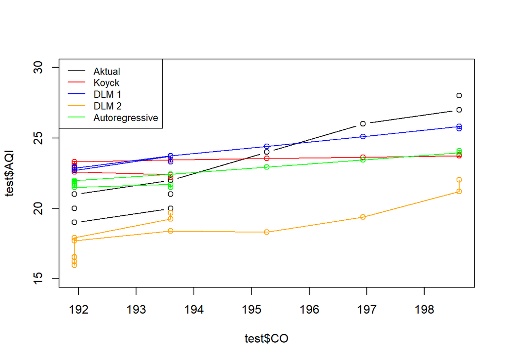

```r
par(mfrow=c(1,1))

plot(test$CO, test$AQI, type="b", col="black", ylim=c(15,30))

points(test$CO, fore.koyck$forecasts, col="red");   lines(test$CO, fore.koyck$forecasts, col="red")
points(test$CO, fore.dlm$forecasts, col="blue");    lines(test$CO, fore.dlm$forecasts, col="blue")
points(test$CO, fore.dlm2$forecasts, col="orange"); lines(test$CO, fore.dlm2$forecasts, col="orange")
points(test$CO, fore.ardl$forecasts, col="green");  lines(test$CO, fore.ardl$forecasts, col="green")

legend("topleft",
       c("Aktual", "Koyck","DLM 1","DLM 2", "Autoregressive"),
       lty=1, col=c("black","red","blue","orange","green"), cex=0.8)
```